# Use Case “Insurance SCR” - Main effects

gg

2024-07-31

# 1 Introduction

While the use case arises out of a question about life insurance within Solvency II no familiarity with either life insurance or Solvency II is assumed or required. This report can be read and understood on a stand alone basis.

It is the first of a set of five reports on this use case. The five reports are * A consecutive set of three reports covering variance decomposition “report_scr_maineff”, “report_scr_quadratic” and “report_scr_NonParametric”. Since they build on each other and the models complexity is gradually increased, it is probably best to read them in this sequence. * A report focusing on tails and tail measures “report_scr_Tail” * A report performing gradient analysis “report_gradient”.

The latter two reports cover independent aspects and do not directly reference each other or the former three reports on variance analysis. The gradient analysis is done using PyTorch’s auto-differentiation. Hence, it assumes basic familiarity with using Python runtime environments. But the script contains references to detailed installation instructions.

All other reports are pure R and should run out-of-the-box after installation of the required packages. All packages can be found on CRAN or a mirror.

## 1.1 Scope and goals of this report

The scope of the report is mainly educational. It does not provide a best-practice approach to explainable AI in general or the interpretation of this specific use case in particular. Its goals are limited to show some of the challenges encountered and some of the solutions available. Accordingly, the models discussed are quite basic and the approach to model selection, calibration and validation somewhat casual. Hopefully the reader is not disappointed by discovering that this first report covers only the most simple main-effects linear model. Even though these models are considered by some as “inherently interpretable”, they do raise very similar issues to those encountered in more complex models. Generalisations to more elaborate models are possible since the methods discussed are model agnostic. This is evidenced by the later reports covering linear models with interactions and non-parametric models. Furthermore, starting with these models serves as a reminder that explainability is neither a new requirement nor a desire restricted to machine learning. Finally, it makes sense from an analysis perspective to start with the most simple case and take it from there.

In line with those goals the R-programming is basic and avoids idiosyncratic constructions of the language. Where reasonable, explicit programming is preferred over the use of packages or libraries, even though a best-practice approach would avoid such reinventing the wheel. Nevertheless, in many cases examples using dedicated libraries are provided in addition to the do-it-yourself code examples.

## 1.2 The methods

Following the taxonomy of [Molnar] the methods discussed here are *global* and *model-agnostic*. From a practical perspective this means:

- Global: Each method produces one single set of statistics for the model and dataset as a whole.
- Model agnostic: Those statistics are derived solely by using information obtained by the calibrated model’s `predict` method/function.

That said, there are several occasions, where the white-box nature of linear models is exploited to gain better insights.

The report focuses on variance as key statistic. The overarching idea may be described as feature importance by variance attribution. Variance attribution takes the familiar concept of $R2R2$ as a share of variance explained by a model and pushes this further by attributing this share to the input variables. Variance as key statistic makes sense because:

- It is a familiar concept even vis-a-vis non-technical stakeholders.
- It is a natural measure of complexity: A random variable with near zero variance is close to constant. Variance can also be related to L2 norms quantifying the “wiggliness” of functions.
- It is closely related to the very convenient square error loss function.

Variance attribution is useful to determine the impact and importance of input variables in a quantitative and rigorous fashion. Being able to answer the natural question “What are the most important inputs?” is a key requirement when explaining a model.

## 1.3 Use case and data

Since the actuarial ideas behind this use case and reasons for its relevance are described in [usecase](https://aktuar.de/en/practice-areas/data-science/use-cases/use_case2/Pages/default.aspx), it suffices here to give a very condensed description which focuses solely on those aspects which are relevant for variance attribution. As stated above no familiarity of the actuarial raison d’etre of the use case is necessary to follow the report.

The use case boils down to a classical approximation or regression problem. The goal is to find an approximation $ff$ to an unknown target function $fˇ=E[y|X]fˇ=E[y|X]$ where the sole information about $fˇfˇ$ is a dataset $(y(i),x(i))(y(i),x(i))$ with inputs $x(i)x(i)$ and responses $y(i)y(i)$. The residuals $ϵ(i)=y(i)−fˇ(x(i))ϵ(i)=y(i)−fˇ(x(i))$ are corrupting noise; it is not possible to observe the point evaluations $fˇ(x(i))fˇ(x(i))$ directly.

In addition, due to confidentiality, the actual meaning of the input variables is unknown which prevents applying any a-priori knowledge to the problem. Furthermore, no information about the distribution of the errors is available for this dataset.

The use case itself imposes no natural definition of the norm for approximation. But because we try to approximate a conditional expectation, squared error is the natural choice as loss function for calibration of the models’ parameters. Accordingly everywhere in this and the subsequent reports squared error is used as loss function.

There are in total three datasets or “portfolios” available but this report only covers the first one.

The following first code block reads in data and the required libraries.

```r
knitr::opts_chunk$set(echo=TRUE, cache = TRUE, cache.comments=FALSE, comment=NA, out.width="90%", attr.source=".numberLines")

suppressPackageStartupMessages(library(knitr))
suppressPackageStartupMessages(library(kableExtra))
suppressPackageStartupMessages(library(ggplot2))
suppressPackageStartupMessages(library(waterfalls))
suppressPackageStartupMessages(library(gtools))
suppressPackageStartupMessages(library(sensitivity))

# seed for reproducibility
set.seed(4711)
datadir = "./data/"

# Number of portfolio (change this to 2 or 3 on your own risk)
ipf = 1

# data (.csv) files
fnm_xtrain = paste0(datadir,"Portfolio", ipf, "/train_input.csv")
fnm_ytrain = paste0(datadir,"Portfolio", ipf, "/train_result.csv")

xtrain = as.matrix(read.csv(fnm_xtrain)[,-1])

nxtrain = dim(xtrain)[1]
nrf = dim(xtrain)[2]
# names of input variables
nm_x = paste0("x", seq.int(1,nrf))
colnames(xtrain) = nm_x

# prepare response aka y
ytrain = as.matrix(read.csv(fnm_ytrain)[,-1])
```

The dataset `xtrain` consists of 32768 observations of 13 attributes each. There are no categorical variables hence all inputs are reals.

## 1.4 Some statistics of the inputs

Unless explicitly mentioned otherwise all probabilities and statistics always refer to the empirical measure as defined by the dataset `xtrain` or subsets thereof.

### 1.4.1 Marginal distribution

All margins of the inputs except the 7th input variable $x7x7$ are uniform. As examples the exhibit below shows the empirical CDFs of $x1x1$ and $x7x7$

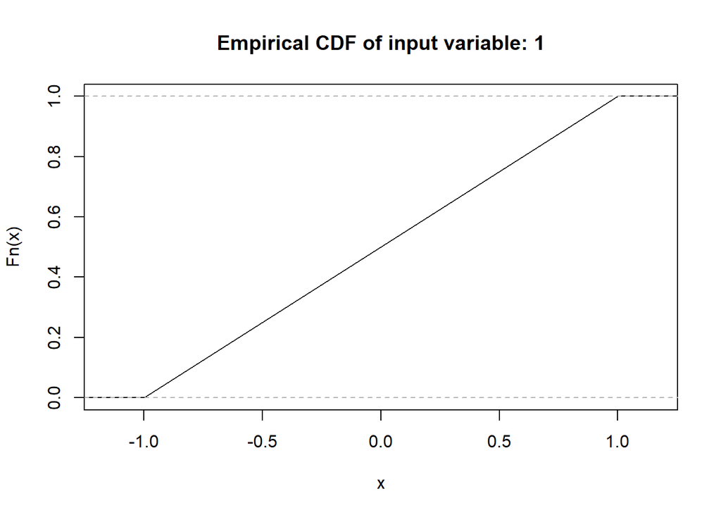

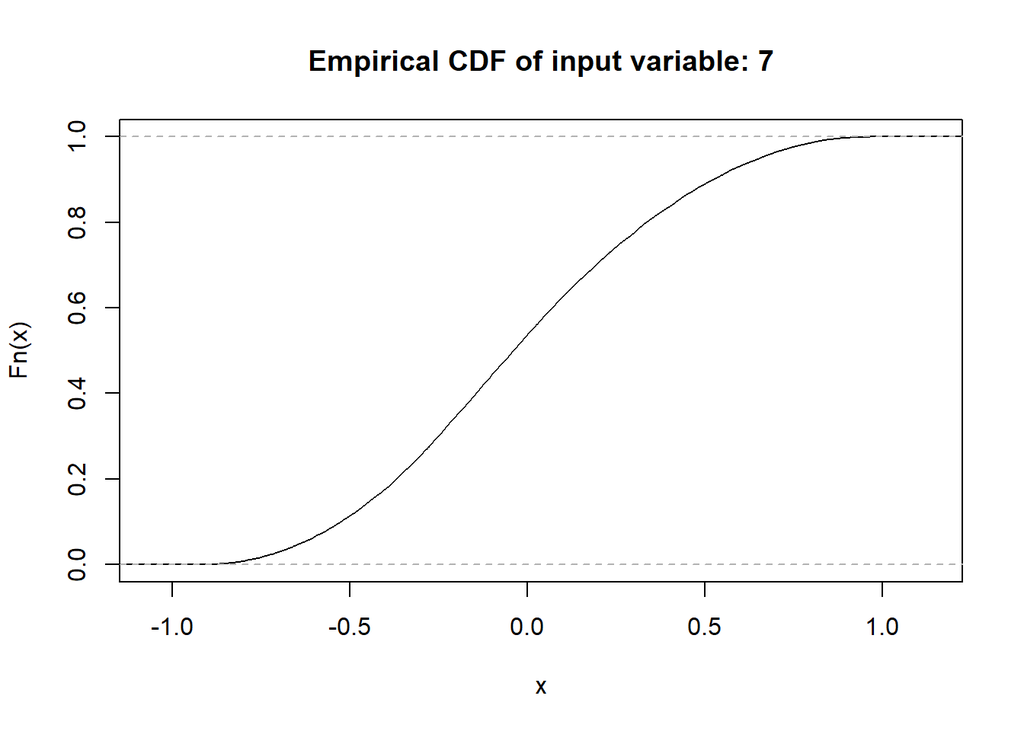

```r
allrf = c(1, 7)

for(irf in allrf){
  plot(ecdf(xtrain[,irf]), main=paste0("Empirical CDF of input variable: ", irf))
}
```

### 1.4.2 Correlation

The dependence structure of the inputs is not known, but empirical correlations can be readily computed.

```r
cormat = cor(xtrain)
idxpair = which(lower.tri(matrix(0, nrf, nrf)), arr.ind = TRUE)
tmp = cbind(round(cormat[idxpair] * 100, 2), idxpair)
tmp = tmp[order(abs(tmp[,1]), decreasing = TRUE),]
colnames(tmp) = c("correlation", colnames(idxpair))
ntmp = 4
tmp[1:ntmp,]
```

```
     correlation row col
[1,]      -60.36   7   1
[2,]        4.94   7   3
[3,]        4.74   7   2
[4,]       -0.02  12   1
```

The table above shows the top 4 correlations in percent sorted by decreasing absolute value. Again variable $x7x7$ is special because it is the only one with significant correlations (strongly to the 1st and less so to the 3rd and 2nd variable) while all other correlations are near zero[^1].

The relationship between $x1x1$ and $x7x7$ is further evidenced by the following scatter plot.

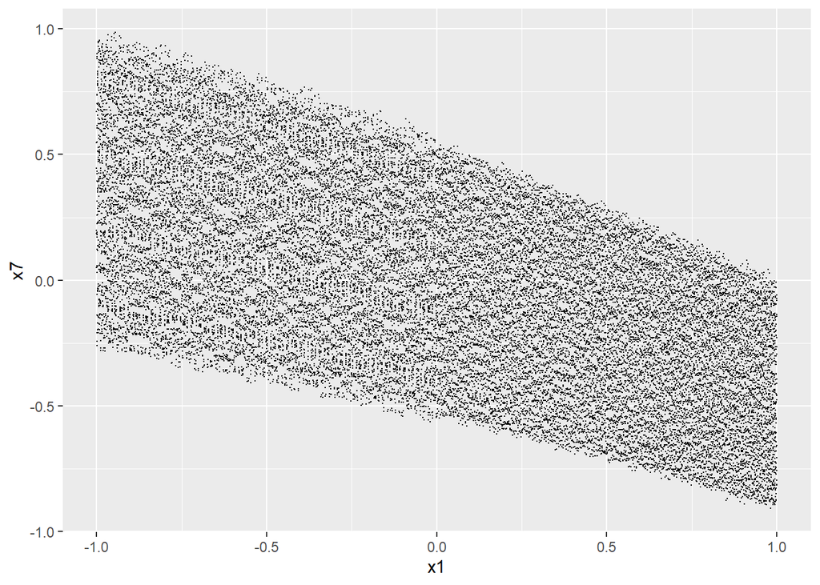

```r
print(
  ggplot(data.frame(x1 = xtrain[,1], x7=xtrain[,7]), aes(x=x1, y=x7)) +
    geom_point(size=0.1) )
```

The domain is clearly non-rectangular, which creates the negative correlation. The regular patterns are due to the dataset being generated by a quasi Monte Carlo sequence.

# 2 Main effects model

## 2.1 Model definition and fit

As mentioned above $d=d=$ 13 is the number of attributes or input variables. The fit to determine the model’s parameters is done by least squares on a subset chosen iid from the full dataset.